# Arima Modeling

**c. Write your own code to generate data from an MA(1) model with** θ1=0.6 **and** σ2=1**.**

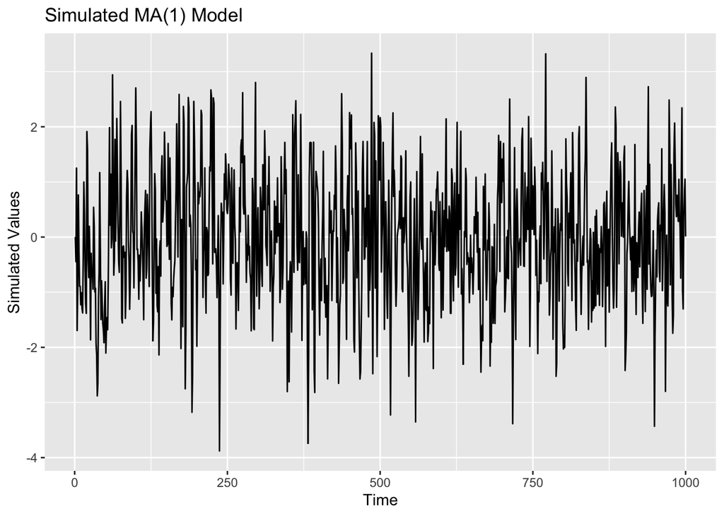

```r
set.seed(1234)
y <- numeric(1000)
e <- rnorm(1000)
for (i in 2:1000) {
  y[i] <- e[i] + 0.6 * e[i - 1]
}
sim_ma <- tsibble(idx = seq_len(1000), y = y, index = idx)


sim_ma |>
  autoplot(y) + labs(title = "Simulated MA(1) Model",
                     x = "Time",
                     y = "Simulated Values")
```

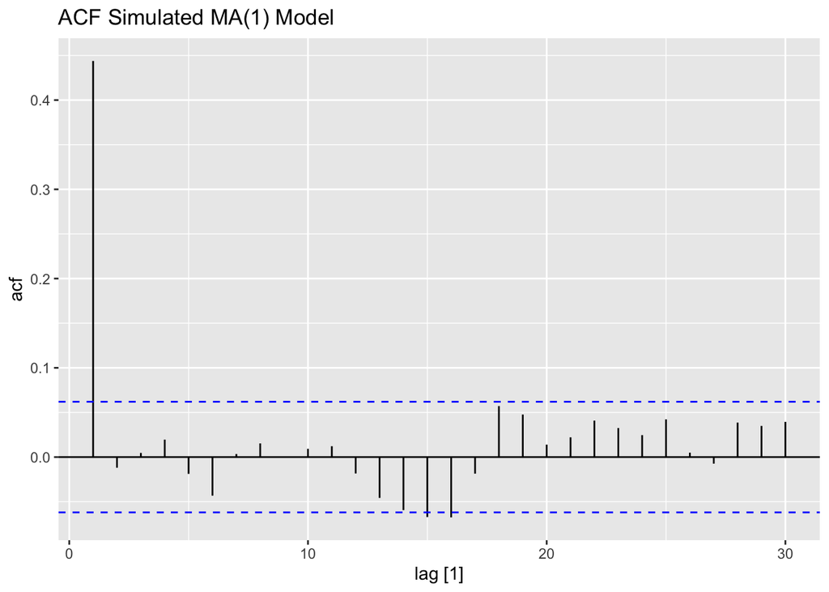

```r
sim_ma |>
  ACF(y) |>
  autoplot() + labs(title = "ACF Simulated MA(1) Model")
```

**D. Produce a time plot for the series. How does the plot change as you change** θ1**?**

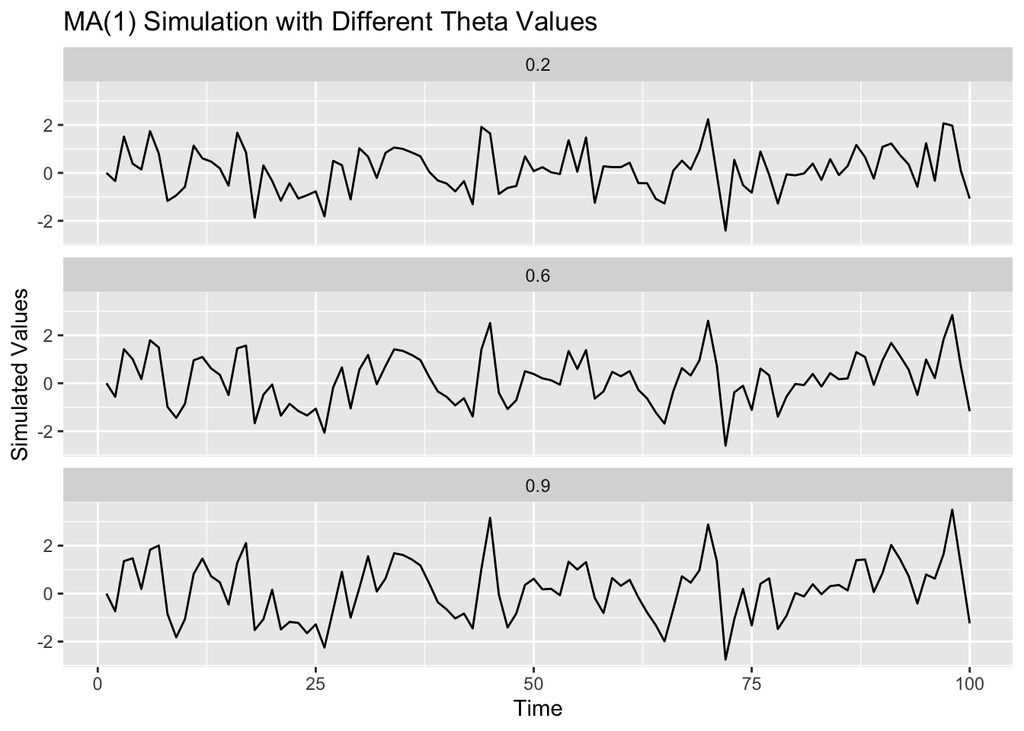

```r
set.seed(123)
e <- rnorm(100)

simulate_ma1 <- function(theta) {
  y <- numeric(100)

  for (i in 2:100) {
    y[i] <- e[i] + theta * e[i - 1]
  }

  return(y)
}

sim_compare_ma <- tibble(
  idx = rep(1:100, 3),
  theta = rep(c("0.2", "0.6", "0.9"), each = 100),
  y = c(
    simulate_ma1(0.2),
    simulate_ma1(0.6),
    simulate_ma1(0.9)
  )
)

ggplot(sim_compare_ma, aes(x = idx, y = y)) +
  geom_line() +
  facet_wrap(~ theta, ncol = 1) +
  labs(
    title = "MA(1) Simulation with Different Theta Values",
    x = "Time",
    y = "Simulated Values"
  )
```

**##Interpretation:**

As \(\theta_1\) increases from 0.2 to 0.9, the previous error has a stronger influence on the current observation. The lag-1 autocorrelation increases over this range, while the theoretical autocorrelation remains zero beyond lag 1. Unlike an AR(1), the effect of a shock in an MA(1) lasts only through the following observation.

**e. Generate data from an ARMA(1,1) model with** ϕ1=0.6θ1=0.6 **and** σ2=1**.**

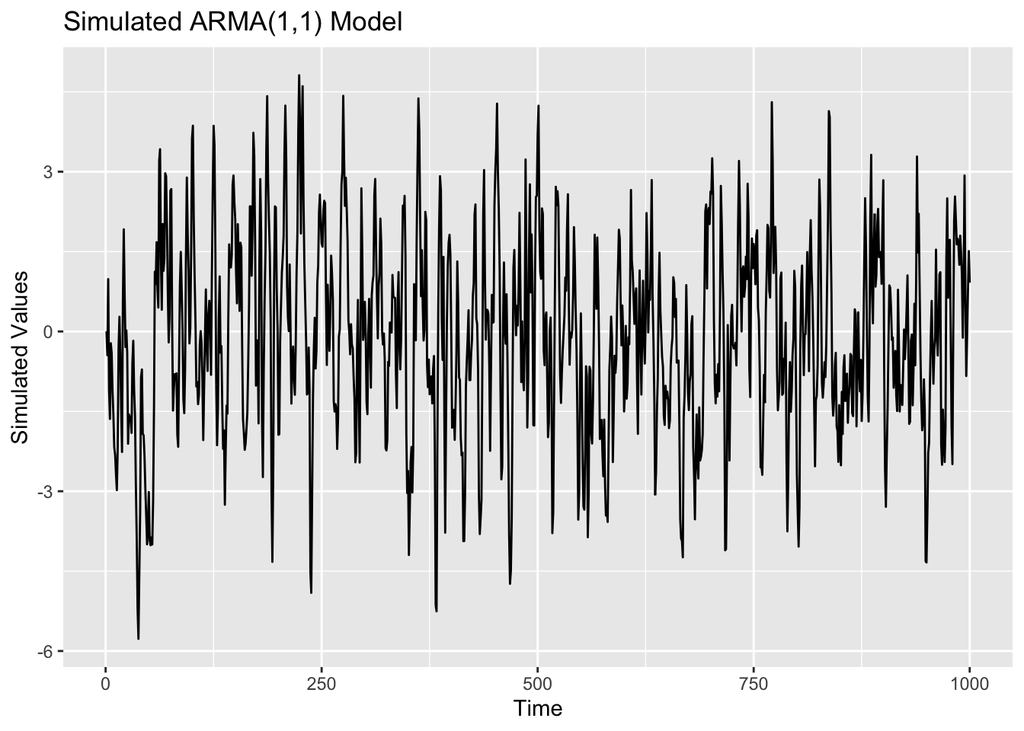

```r
set.seed(1234)

y <- numeric(1000)
e <- rnorm(1000, mean = 0, sd = 1)

for (i in 2:1000) {
  y[i] <- 0.6 * y[i - 1] + e[i] + 0.6 * e[i - 1]
}

sim_arma <- tsibble(
  idx = seq_len(1000),
  y = y,
  index = idx
)

sim_arma |>
  autoplot(y) +
  labs(
    title = "Simulated ARMA(1,1) Model",
    x = "Time",
    y = "Simulated Values"
  )
```

**f. Generate data from an AR(2) model with** ϕ1=−0.8**,** ϕ2=0.3 **and** σ2=1**. (Note that these parameters will give a non-stationary series.)**

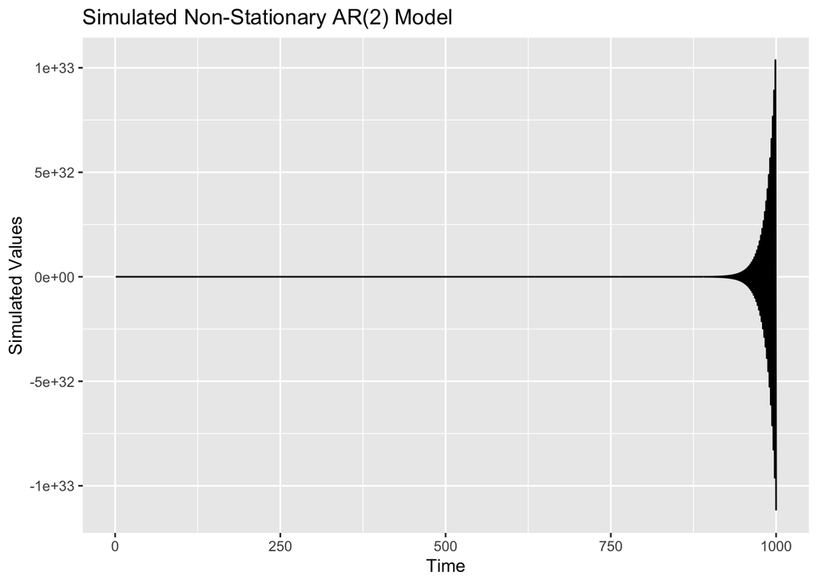

```r
library(fpp3)

set.seed(1234)

y <- numeric(1000)
e <- rnorm(1000, mean = 0, sd = 1)

for (i in 3:1000) {
  y[i] <- -0.8 * y[i - 1] + 0.3 * y[i - 2] + e[i]
}

sim_ar2 <- tsibble(
  idx = seq_len(1000),
  y = y,
  index = idx
)

sim_ar2 |>
  autoplot(y) +
  labs(
    title = "Simulated Non-Stationary AR(2) Model",
    x = "Time",
    y = "Simulated Values"
  )
```

**g. Graph the latter two series and compare them.**

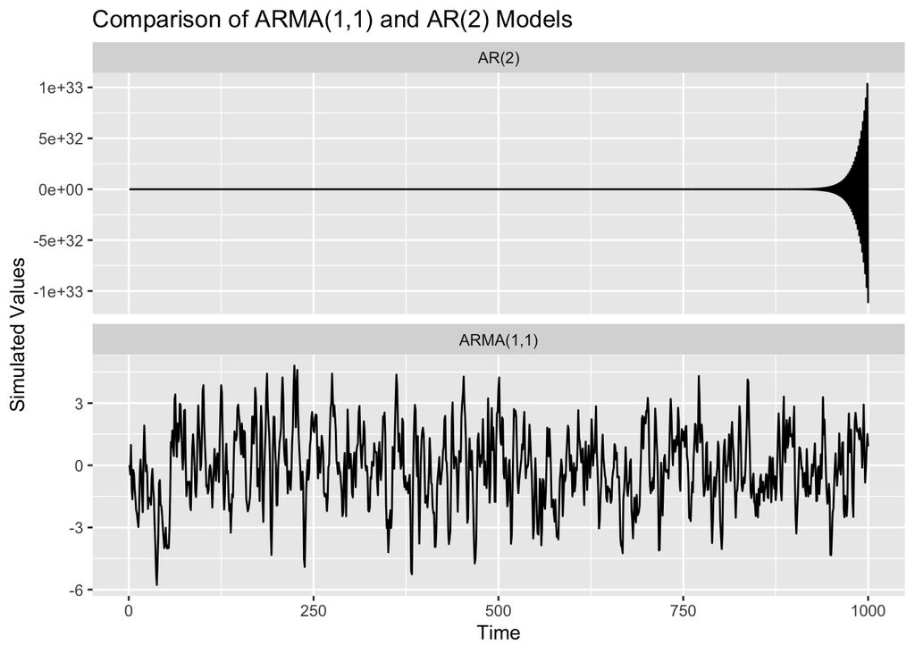

```r
library(fpp3)

comparison <- bind_rows(
  sim_arma |>
    as_tibble() |>
    mutate(Model = "ARMA(1,1)"),

  sim_ar2 |>
    as_tibble() |>
    mutate(Model = "AR(2)")
)

ggplot(comparison, aes(x = idx, y = y)) +
  geom_line() +
  facet_wrap(~ Model, ncol = 1, scales = "free_y") +
  labs(
    title = "Comparison of ARMA(1,1) and AR(2) Models",
    x = "Time",
    y = "Simulated Values"
  )
```

**##Interpretation:**

The ARMA(1,1) series fluctuates around zero without showing a persistent upward or downward trend, indicating stationary behavior. In contrast, the AR(2) series exhibits increasingly large oscillations as time progresses. This occurs because the AR(2) coefficients violate the stationarity conditions, causing the process to become explosive. Therefore, the ARMA(1,1) series maintains relatively stable variability, whereas the AR(2) series does not.

**9.7 Consider `aus_airpassengers`, the total number of passengers (in millions) from Australian air carriers for the period 1970-2011.**

a. **Use `ARIMA()` to find an appropriate ARIMA model. What model was selected? Check that the residuals look like white noise. Plot forecasts for the next 10 periods.**

```r
air_data <- aus_airpassengers |>
  filter(Year <= 2011)

fit_arima <- air_data |>
  model(ARIMA(Passengers, stepwise = FALSE, approx = FALSE))
fit_arima
```

```
# A mable: 1 x 1
  `ARIMA(Passengers, stepwise = FALSE, approx = FALSE)`
                                                <model>
1                                        <ARIMA(0,2,1)>
```

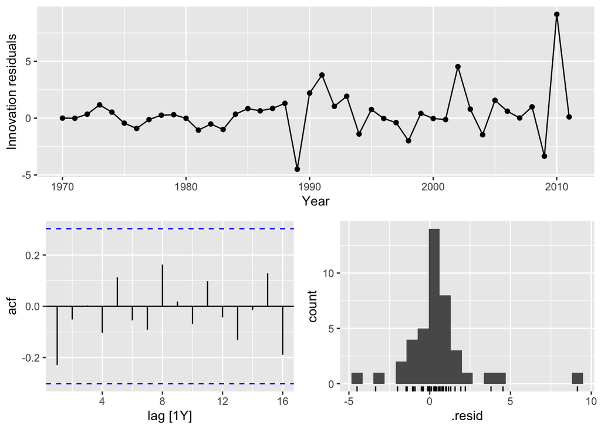

```r
# Check the residuals
fit_arima |>
  gg_tsresiduals()
```

```r
report(fit_arima)
```

```
Series: Passengers
Model: ARIMA(0,2,1)

Coefficients:
          ma1
      -0.8756
s.e.   0.0722

sigma^2 estimated as 4.671:  log likelihood=-87.8
AIC=179.61   AICc=179.93   BIC=182.99
```

```r
# Check for white noise
fit_arima |>
  augment() |>
  features(.innov, ljung_box, lag = 10, dof = 1)
```

```
# A tibble: 1 × 3
  .model                                              lb_stat lb_pvalue
  <chr>                                                 <dbl>     <dbl>
1 ARIMA(Passengers, stepwise = FALSE, approx = FALSE)    6.00     0.740
```

```r
# Plot forecast h = 10
fc_fit_arima <- fit_arima |>
  forecast(h = 10)
fc_fit_arima
```

```
# A fable: 10 x 4 [1Y]
# Key:     .model [1]
   .model                                               Year
   <chr>                                               <dbl>
 1 ARIMA(Passengers, stepwise = FALSE, approx = FALSE)  2012
 2 ARIMA(Passengers, stepwise = FALSE, approx = FALSE)  2013
 3 ARIMA(Passengers, stepwise = FALSE, approx = FALSE)  2014
 4 ARIMA(Passengers, stepwise = FALSE, approx = FALSE)  2015
 5 ARIMA(Passengers, stepwise = FALSE, approx = FALSE)  2016
 6 ARIMA(Passengers, stepwise = FALSE, approx = FALSE)  2017
 7 ARIMA(Passengers, stepwise = FALSE, approx = FALSE)  2018
 8 ARIMA(Passengers, stepwise = FALSE, approx = FALSE)  2019
 9 ARIMA(Passengers, stepwise = FALSE, approx = FALSE)  2020
10 ARIMA(Passengers, stepwise = FALSE, approx = FALSE)  2021
# ℹ 2 more variables: Passengers <dist>, .mean <dbl>
```

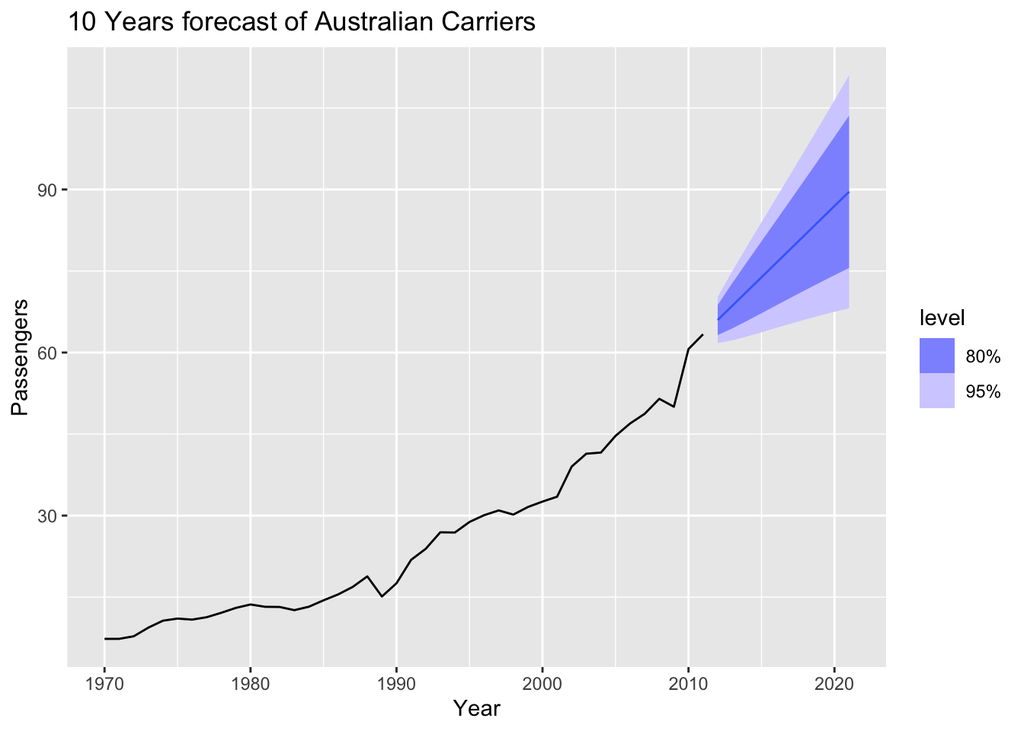

```r
# Plot

fc_fit_arima |> autoplot(air_data) + labs(title = "10 Years forecast of Australian Carriers")
```

**b. Write the model in terms of the backshift operator.**

**c. Plot forecasts from an ARIMA(0,1,0) model with drift and compare these to part a**

```r
fit_arima_drif <- air_data |>
  model(ARIMA(Passengers ~ 1 + pdq(0, 1, 0)))
fit_arima_drif
```

```
# A mable: 1 x 1
  `ARIMA(Passengers ~ 1 + pdq(0, 1, 0))`
                                 <model>
1                <ARIMA(0,1,0) w/ drift>
```

```r
report(fit_arima_drif)
```

```
Series: Passengers
Model: ARIMA(0,1,0) w/ drift

Coefficients:
      constant
        1.3669
s.e.    0.3319

sigma^2 estimated as 4.629:  log likelihood=-89.08
AIC=182.17   AICc=182.48   BIC=185.59
```

```r
# Check for white noise
fit_arima_drif |>
  augment() |>
  features(.innov, ljung_box, lag = 10, dof = 0)
```

```
# A tibble: 1 × 3
  .model                               lb_stat lb_pvalue
  <chr>                                  <dbl>     <dbl>
1 ARIMA(Passengers ~ 1 + pdq(0, 1, 0))    4.92     0.897
```

```r
# Plot forecast h = 10
fc_fit_arima_drif <- fit_arima_drif |>
  forecast(h = 10)
fc_fit_arima_drif
```

```
# A fable: 10 x 4 [1Y]
# Key:     .model [1]
   .model                                Year
   <chr>                                <dbl>
 1 ARIMA(Passengers ~ 1 + pdq(0, 1, 0))  2012
 2 ARIMA(Passengers ~ 1 + pdq(0, 1, 0))  2013
 3 ARIMA(Passengers ~ 1 + pdq(0, 1, 0))  2014
 4 ARIMA(Passengers ~ 1 + pdq(0, 1, 0))  2015
 5 ARIMA(Passengers ~ 1 + pdq(0, 1, 0))  2016
 6 ARIMA(Passengers ~ 1 + pdq(0, 1, 0))  2017
 7 ARIMA(Passengers ~ 1 + pdq(0, 1, 0))  2018
 8 ARIMA(Passengers ~ 1 + pdq(0, 1, 0))  2019
 9 ARIMA(Passengers ~ 1 + pdq(0, 1, 0))  2020
10 ARIMA(Passengers ~ 1 + pdq(0, 1, 0))  2021
# ℹ 2 more variables: Passengers <dist>, .mean <dbl>
```

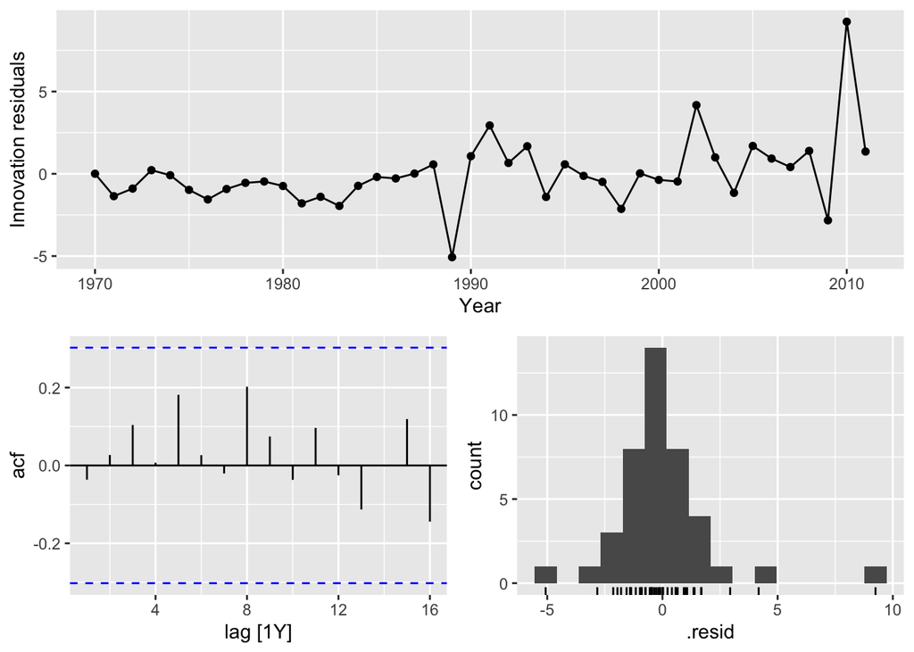

```r
# Residuals plot
fit_arima_drif |>
  gg_tsresiduals()
```

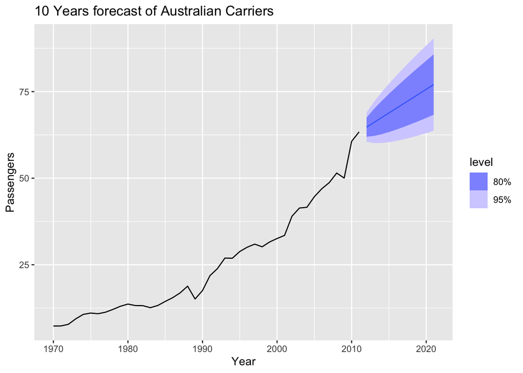

```r
# Plot


fc_fit_arima_drif |> autoplot(air_data) + labs(title = "10 Years forecast of Australian Carriers")
```

```r
comparison_models <- air_data |>
  model(
    ARIMA_021 = ARIMA(
      Passengers,
      stepwise = FALSE,
      approx = FALSE
    ),
    ARIMA_Drift = ARIMA(
      Passengers ~ 1 + pdq(0, 1, 0)
    )
  )

comparison_models |>
  glance() |>
  select(.model, AIC, AICc, BIC) |>
  arrange(AICc)
```

```
# A tibble: 2 × 4
  .model        AIC  AICc   BIC
  <chr>       <dbl> <dbl> <dbl>
1 ARIMA_021    180.  180.  183.
2 ARIMA_Drift  182.  182.  186.
```

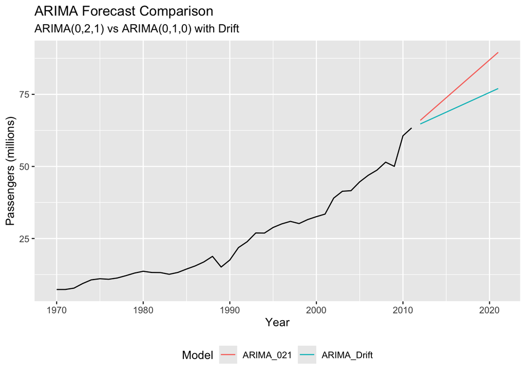

```r
comparison_fc <- comparison_models |>
  forecast(h = 10)

comparison_fc |>
  autoplot(air_data, level = NULL) +
  labs(
    title = "ARIMA Forecast Comparison",
    subtitle = "ARIMA(0,2,1) vs ARIMA(0,1,0) with Drift",
    x = "Year",
    y = "Passengers (millions)",
    colour = "Model"
  ) +
  theme(
    legend.position = "bottom"
  )
```

**d. Plot forecasts from an ARIMA(2,1,2) model with drift and compare these to parts a and c. Remove the constant and see what happens.**

```r
fit_arima_drift <- air_data |>
  model(ARIMA(Passengers ~ 1 + pdq(2, 1, 2)))
fit_arima_drift
```

```
# A mable: 1 x 1
  `ARIMA(Passengers ~ 1 + pdq(2, 1, 2))`
                                 <model>
1                <ARIMA(2,1,2) w/ drift>
```

```r
report(fit_arima_drift)
```

```
Series: Passengers
Model: ARIMA(2,1,2) w/ drift

Coefficients:
         ar1      ar2      ma1     ma2  constant
      1.4706  -0.5111  -1.5744  0.6784    0.0645
s.e.  0.3795   0.3564   0.3091  0.2679    0.0292

sigma^2 estimated as 4.747:  log likelihood=-87.74
AIC=187.47   AICc=189.94   BIC=197.75
```

```r
# Check for white noise
fit_arima_drift |>
  augment() |>
  features(.innov, ljung_box, lag = 10, dof = 0)
```

```
# A tibble: 1 × 3
  .model                               lb_stat lb_pvalue
  <chr>                                  <dbl>     <dbl>
1 ARIMA(Passengers ~ 1 + pdq(2, 1, 2))    2.75     0.987
```

```r
# Plot forecast h = 10
fc_fit_arima_drift <- fit_arima_drift |>
  forecast(h = 10)
fc_fit_arima_drift
```

```
# A fable: 10 x 4 [1Y]
# Key:     .model [1]
   .model                                Year
   <chr>                                <dbl>
 1 ARIMA(Passengers ~ 1 + pdq(2, 1, 2))  2012
 2 ARIMA(Passengers ~ 1 + pdq(2, 1, 2))  2013
 3 ARIMA(Passengers ~ 1 + pdq(2, 1, 2))  2014
 4 ARIMA(Passengers ~ 1 + pdq(2, 1, 2))  2015
 5 ARIMA(Passengers ~ 1 + pdq(2, 1, 2))  2016
 6 ARIMA(Passengers ~ 1 + pdq(2, 1, 2))  2017
 7 ARIMA(Passengers ~ 1 + pdq(2, 1, 2))  2018
 8 ARIMA(Passengers ~ 1 + pdq(2, 1, 2))  2019
 9 ARIMA(Passengers ~ 1 + pdq(2, 1, 2))  2020
10 ARIMA(Passengers ~ 1 + pdq(2, 1, 2))  2021
# ℹ 2 more variables: Passengers <dist>, .mean <dbl>
```

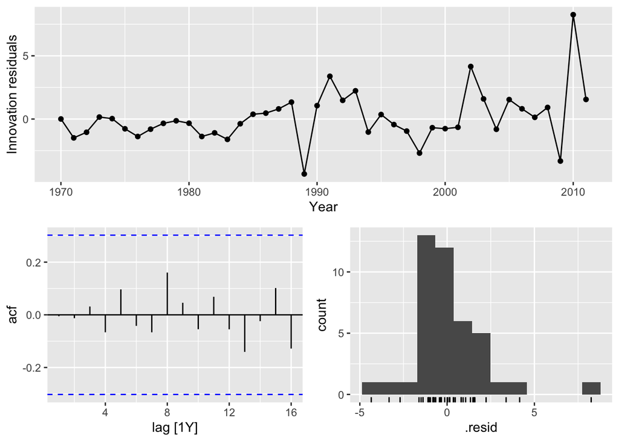

```r
# Residuals plot
fit_arima_drift |>
  gg_tsresiduals()
```

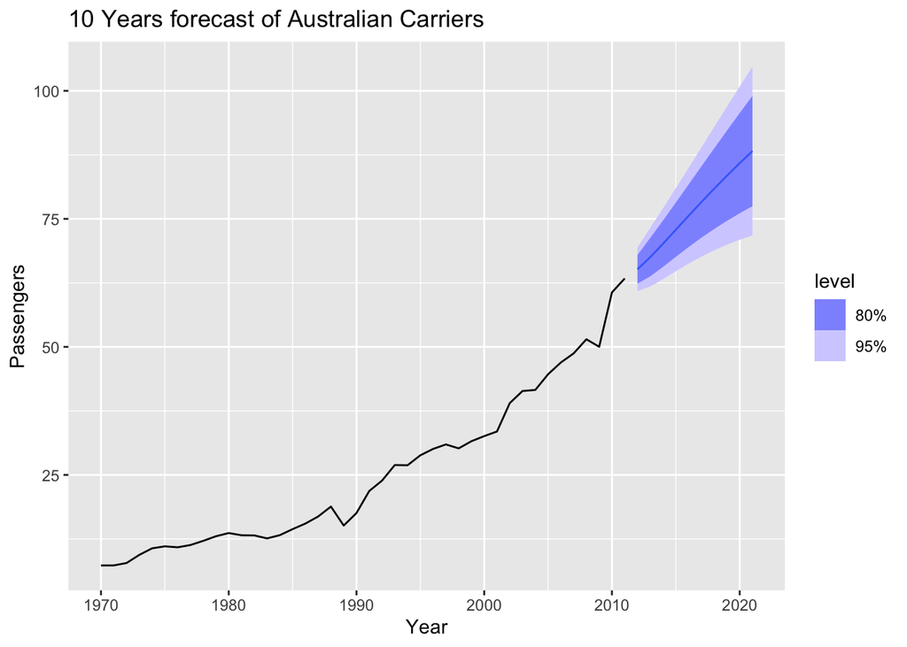

```r
# Plot


fc_fit_arima_drift |> autoplot(air_data) + labs(title = "10 Years forecast of Australian Carriers")
```

```r
comparison_models2 <- air_data |>
  model(
    ARIMA_021 = ARIMA(
      Passengers,
      stepwise = FALSE,
      approx = FALSE
    ),

    ARIMA_010_Drift = ARIMA(
      Passengers ~ 1 + pdq(0, 1, 0)
    ),

    ARIMA_212_Drift = ARIMA(
      Passengers ~ 1 + pdq(2, 1, 2)
    ),

    ARIMA_212_NoDrift = ARIMA(
      Passengers ~ 0 + pdq(2, 1, 2)
    )
  )
# Compare model selection criteria
comparison_models2 |>
  glance() |>
  select(.model, AIC, AICc, BIC) |>
  arrange(AICc)
```

```
# A tibble: 3 × 4
  .model            AIC  AICc   BIC
  <chr>           <dbl> <dbl> <dbl>
1 ARIMA_021        180.  180.  183.
2 ARIMA_010_Drift  182.  182.  186.
3 ARIMA_212_Drift  187.  190.  198.
```

```r
# Forecast
comparison_fc2 <- comparison_models2 |>
  forecast(h = 10)


comparison_models2 |>
  augment() |>
  features(.innov, ljung_box, lag = 10, dof = 4)
```

```
# A tibble: 4 × 3
  .model            lb_stat lb_pvalue
  <chr>               <dbl>     <dbl>
1 ARIMA_010_Drift      4.92     0.554
2 ARIMA_021            6.00     0.423
3 ARIMA_212_Drift      2.75     0.840
4 ARIMA_212_NoDrift   NA       NA
```

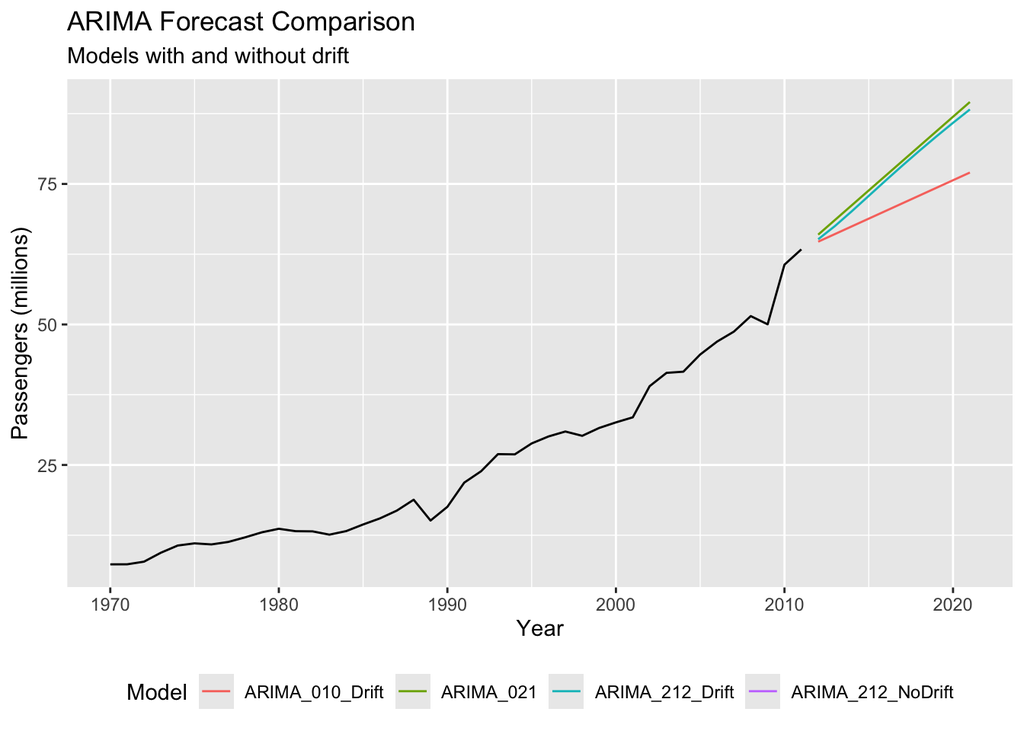

```r
# Plot
comparison_fc2 |>
  autoplot(air_data, level = NULL) +
  labs(
    title = "ARIMA Forecast Comparison",
    subtitle = "Models with and without drift",
    x = "Year",
    y = "Passengers (millions)",
    colour = "Model"
  ) +
  theme(legend.position = "bottom")
```

**e. Plot forecasts from an ARIMA(0,2,1) model with a constant. What happens?**

```r
fit_arima_constant <- air_data |>
  model(ARIMA(Passengers ~ 1 + pdq(0, 2, 1)))
fit_arima_constant
```

```
# A mable: 1 x 1
  `ARIMA(Passengers ~ 1 + pdq(0, 2, 1))`
                                 <model>
1                 <ARIMA(0,2,1) w/ poly>
```

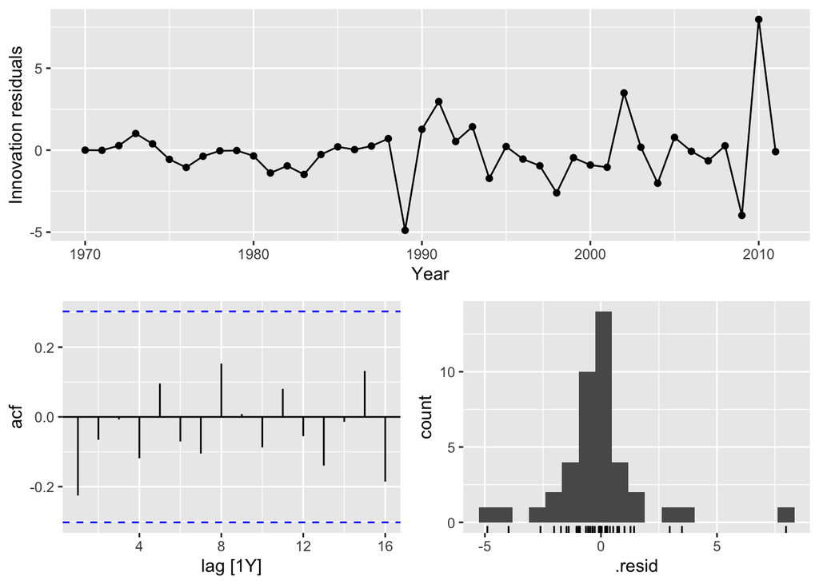

```r
# Check the residuals
fit_arima_constant |>
  gg_tsresiduals()
```

```r
report(fit_arima_constant)
```

```
Series: Passengers
Model: ARIMA(0,2,1) w/ poly

Coefficients:
          ma1  constant
      -1.0000    0.0721
s.e.   0.0709    0.0260

sigma^2 estimated as 4.086:  log likelihood=-85.74
AIC=177.48   AICc=178.15   BIC=182.55
```

```r
# Check for white noise
fit_arima_constant |>
  augment() |>
  features(.innov, ljung_box, lag = 10, dof = 2)
```

```
# A tibble: 1 × 3
  .model                               lb_stat lb_pvalue
  <chr>                                  <dbl>     <dbl>
1 ARIMA(Passengers ~ 1 + pdq(0, 2, 1))    6.19     0.626
```

```r
# Plot forecast h = 10
fc_fit_arima <- fit_arima_constant |>
  forecast(h = 10)
fc_fit_arima
```

```
# A fable: 10 x 4 [1Y]
# Key:     .model [1]
   .model                                Year
   <chr>                                <dbl>
 1 ARIMA(Passengers ~ 1 + pdq(0, 2, 1))  2012
 2 ARIMA(Passengers ~ 1 + pdq(0, 2, 1))  2013
 3 ARIMA(Passengers ~ 1 + pdq(0, 2, 1))  2014
 4 ARIMA(Passengers ~ 1 + pdq(0, 2, 1))  2015
 5 ARIMA(Passengers ~ 1 + pdq(0, 2, 1))  2016
 6 ARIMA(Passengers ~ 1 + pdq(0, 2, 1))  2017
 7 ARIMA(Passengers ~ 1 + pdq(0, 2, 1))  2018
 8 ARIMA(Passengers ~ 1 + pdq(0, 2, 1))  2019
 9 ARIMA(Passengers ~ 1 + pdq(0, 2, 1))  2020
10 ARIMA(Passengers ~ 1 + pdq(0, 2, 1))  2021
# ℹ 2 more variables: Passengers <dist>, .mean <dbl>
```

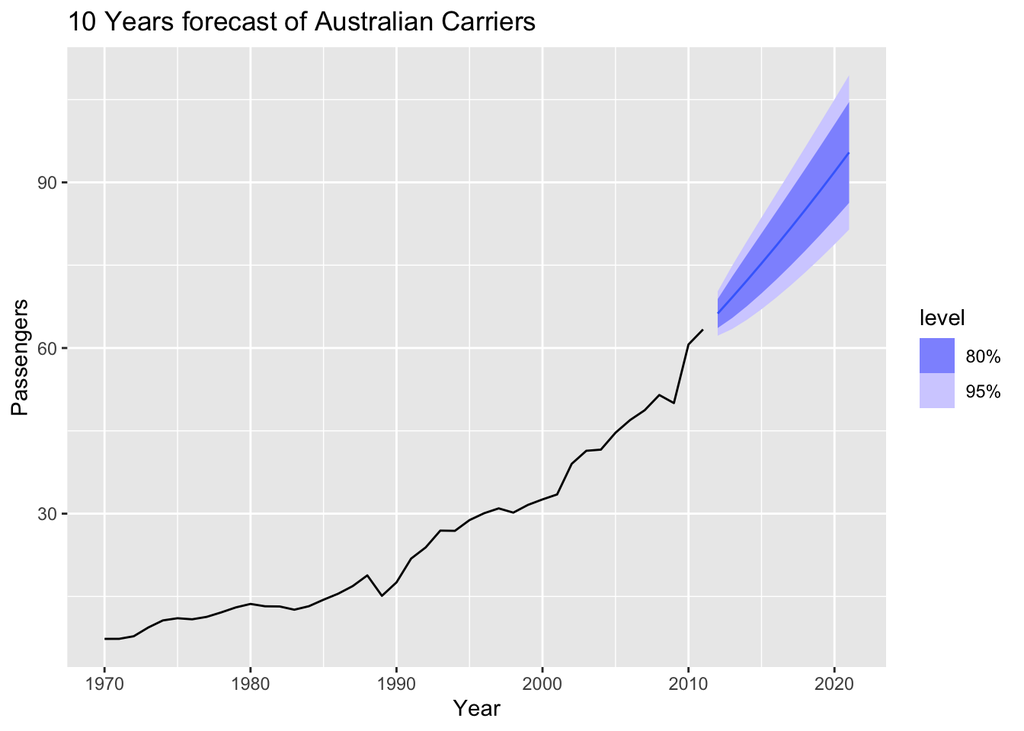

```r
# Plot

fc_fit_arima |> autoplot(air_data) + labs(title = "10 Years forecast of Australian Carriers")
```

**8 For the United States GDP series (from `global_economy`)**

**a. if necessary, find a suitable Box-Cox transformation for the data;**

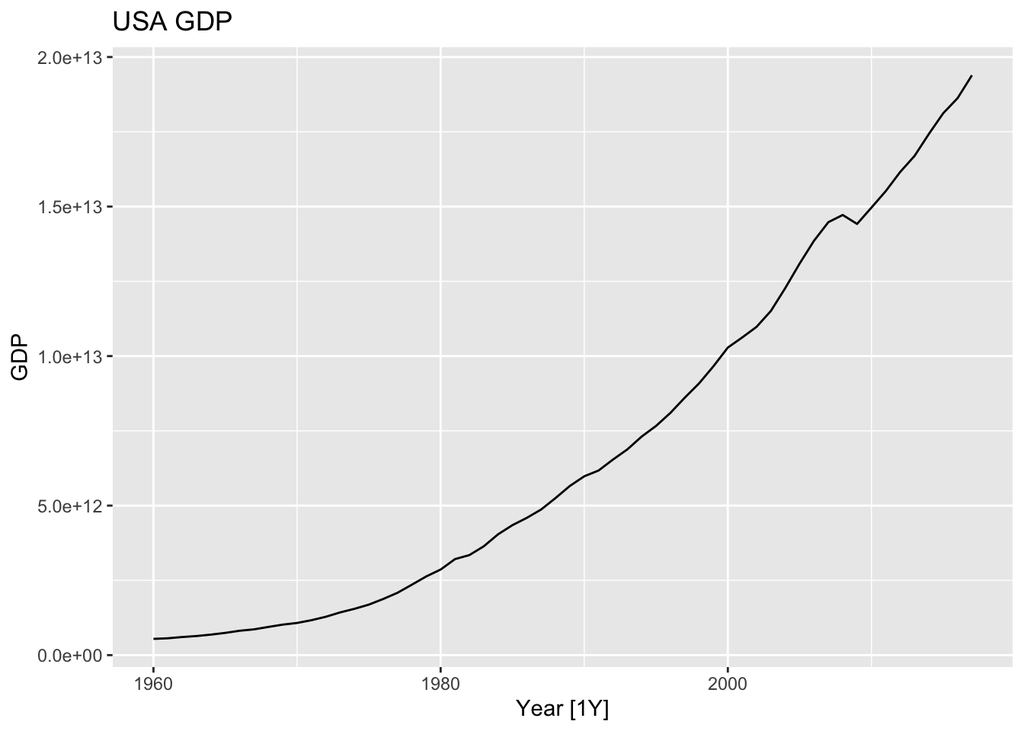

```r
usa_gdp <- global_economy |>
  filter(Country == "United States")

# Plot the original data
usa_gdp |> autoplot(GDP) + labs(title = "USA GDP")
```

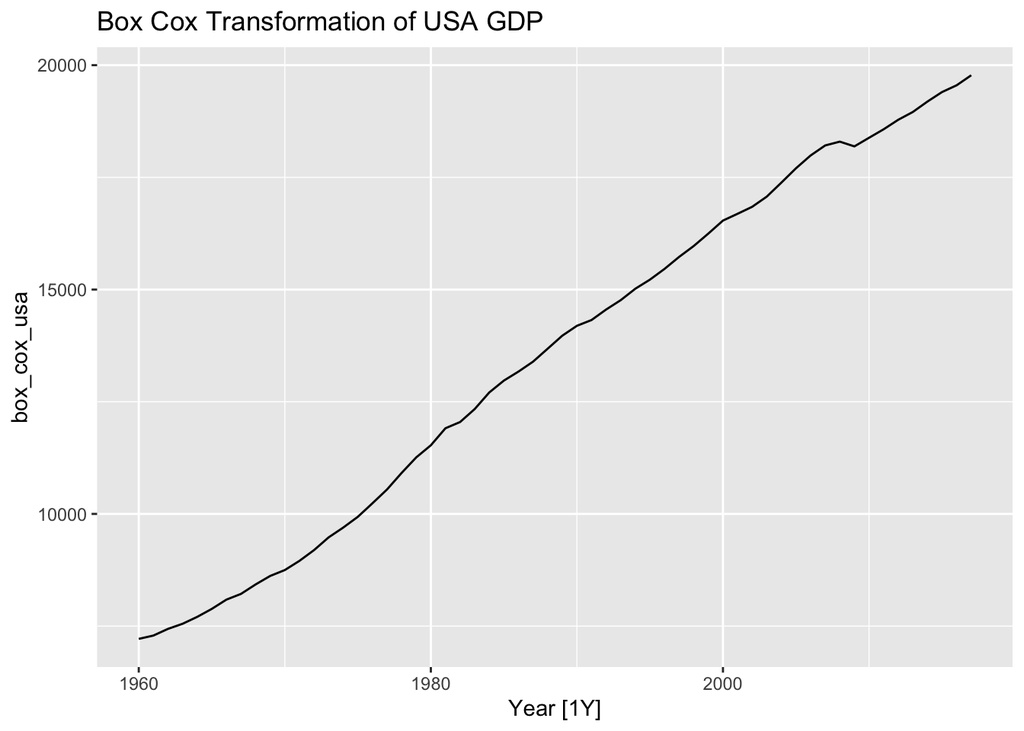

```r
# Find a box cox transformation
lambda <- usa_gdp |>
  features(GDP, guerrero) |>
  pull(lambda_guerrero)

box_cox_trans_usa <- usa_gdp |>
  mutate(box_cox_usa = box_cox(GDP, lambda))

box_cox_trans_usa |> autoplot(box_cox_usa) + labs(title = "Box Cox Transformation of USA GDP")
```

**##Interpretation:**

The original United States GDP series exhibits a strong upward trend, indicating that GDP has increased substantially over time. A Box-Cox transformation was applied using the Guerrero method to identify a suitable transformation parameter. The transformation aims to stabilize the variance and make the series more appropriate for time series modeling. Further differencing may still be required to achieve stationarity.

**b. fit a suitable ARIMA model to the transformed data using `ARIMA()`;**

```r
fit_usa_arima <- box_cox_trans_usa |>
  model(ARIMA(box_cox_usa, stepwise = FALSE, approx = FALSE))
fit_usa_arima
```

```
# A mable: 1 x 2
# Key:     Country [1]
  Country       `ARIMA(box_cox_usa, stepwise = FALSE, approx = FALSE)`
  <fct>                                                        <model>
1 United States                                <ARIMA(1,1,0) w/ drift>
```

```r
report(fit_usa_arima)
```

```
Series: box_cox_usa
Model: ARIMA(1,1,0) w/ drift

Coefficients:
         ar1  constant
      0.4586  118.1822
s.e.  0.1198    9.5047

sigma^2 estimated as 5479:  log likelihood=-325.32
AIC=656.65   AICc=657.1   BIC=662.78
```

**c. try some other plausible models by experimenting with the orders chosen;**

```r
usa_models <- box_cox_trans_usa |>
  model(
    Auto_ARIMA = ARIMA(
      box_cox_usa,
      stepwise = FALSE,
      approx = FALSE
    ),
    ARIMA_111 = ARIMA(
      box_cox_usa ~ 1 + pdq(1, 1, 1)
    ),
    ARIMA_001 = ARIMA(
      box_cox_usa ~ 1 + pdq(0, 0, 1)
    ),
    ARIMA_200 = ARIMA(
      box_cox_usa ~ 1 + pdq(2, 0, 0)
    ),
    ARIMA_210 = ARIMA(
      box_cox_usa ~ 1 + pdq(2, 1, 0)
    )
  )
usa_models |>
  glance() |>
  select(.model, AIC, AICc, BIC) |>
  arrange(AICc)
```

```
# A tibble: 5 × 4
  .model       AIC  AICc   BIC
  <chr>      <dbl> <dbl> <dbl>
1 Auto_ARIMA  657.  657.  663.
2 ARIMA_111   659.  659.  667.
3 ARIMA_210   659.  659.  667.
4 ARIMA_200   683.  684.  691.
5 ARIMA_001  1058. 1058. 1064.
```

##Interpretation:

By trying different models their AICc value are higher so keeping ARIMA(1, 1, 0) is best

**d. choose what you think is the best model and check the residual diagnostics;**

```r
fit_usa_arima <- box_cox_trans_usa |>
  model(ARIMA(box_cox_usa, stepwise = FALSE, approx = FALSE))
fit_usa_arima
```

```
# A mable: 1 x 2
# Key:     Country [1]
  Country       `ARIMA(box_cox_usa, stepwise = FALSE, approx = FALSE)`
  <fct>                                                        <model>
1 United States                                <ARIMA(1,1,0) w/ drift>
```

```r
report(fit_usa_arima)
```

```
Series: box_cox_usa
Model: ARIMA(1,1,0) w/ drift

Coefficients:
         ar1  constant
      0.4586  118.1822
s.e.  0.1198    9.5047

sigma^2 estimated as 5479:  log likelihood=-325.32
AIC=656.65   AICc=657.1   BIC=662.78
```

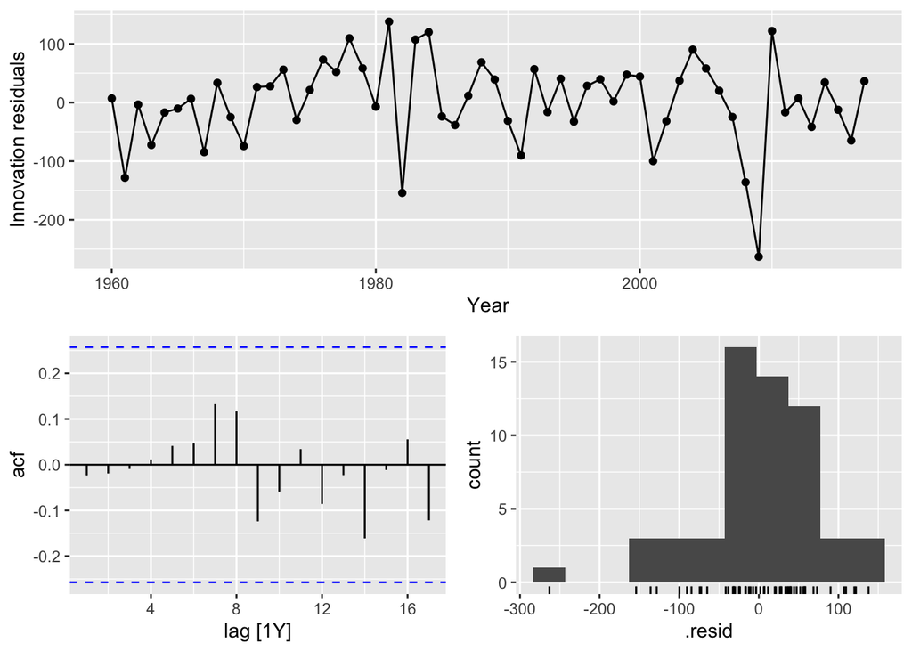

```r
fit_usa_arima |> gg_tsresiduals()
```

```r
fit_usa_arima |>
  augment() |>
  features(
    .innov,
    ljung_box,
    lag = 10,
    dof = 1
  )
```

```
# A tibble: 1 × 4
  Country       .model                                         lb_stat lb_pvalue
  <fct>         <chr>                                            <dbl>     <dbl>
1 United States ARIMA(box_cox_usa, stepwise = FALSE, approx =…    3.81     0.923
```

**##Interpretation:**

The residual diagnostics for the selected ARIMA(1,1,0) model show that the residuals fluctuate around zero without a clear systematic pattern. The ACF plot indicates that the residual autocorrelations are within the approximate 95% significance bounds, suggesting that little serial correlation remains. However, the histogram is not perfectly symmetric, and several unusual residuals are present. The Ljung–Box test provides an additional assessment of whether the residuals behave like white noise.

**e. produce forecasts of your fitted model. Do the forecasts look reasonable?**

```r
fit_usa_arima <- box_cox_trans_usa |>
  model(ARIMA(box_cox_usa, stepwise = FALSE, approx = FALSE))
fit_usa_arima
```

```
# A mable: 1 x 2
# Key:     Country [1]
  Country       `ARIMA(box_cox_usa, stepwise = FALSE, approx = FALSE)`
  <fct>                                                        <model>
1 United States                                <ARIMA(1,1,0) w/ drift>
```

```r
report(fit_usa_arima)
```

```
Series: box_cox_usa
Model: ARIMA(1,1,0) w/ drift

Coefficients:
         ar1  constant
      0.4586  118.1822
s.e.  0.1198    9.5047

sigma^2 estimated as 5479:  log likelihood=-325.32
AIC=656.65   AICc=657.1   BIC=662.78
```

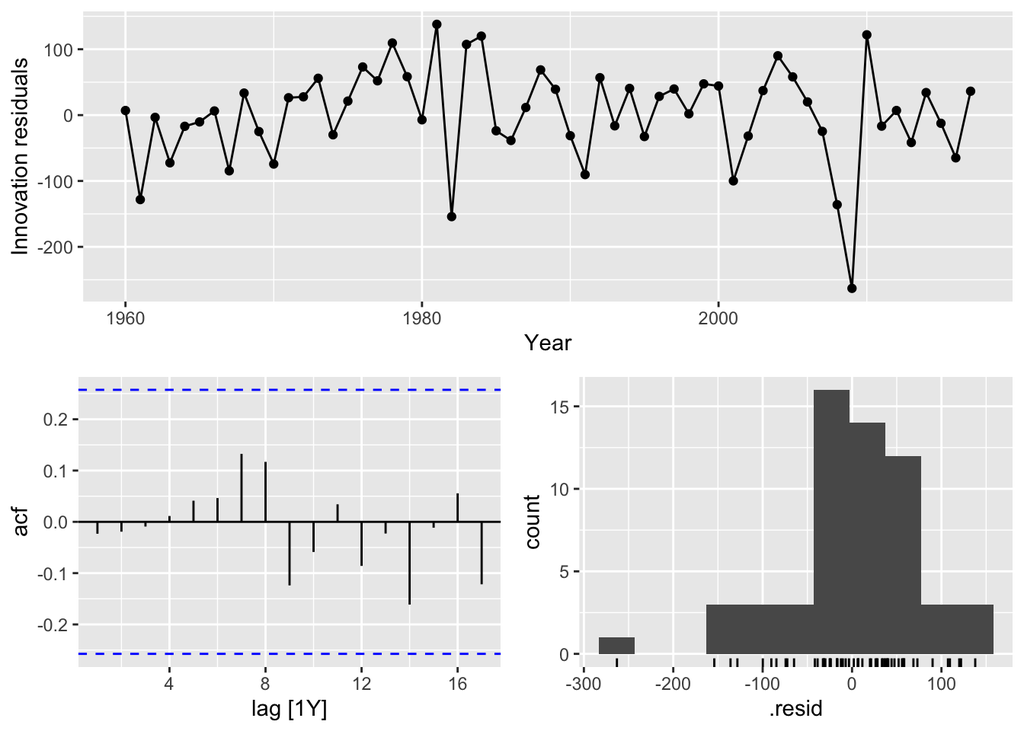

```r
fit_usa_arima |> gg_tsresiduals()
```

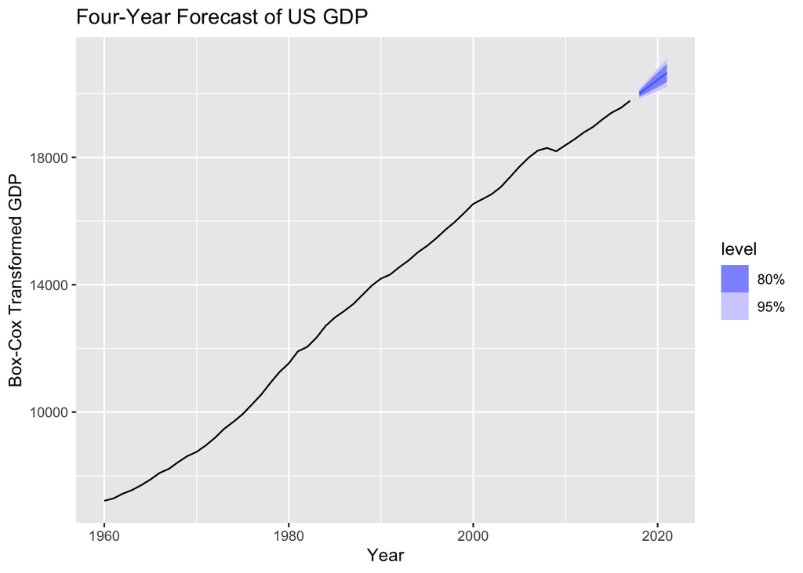

```r
fc_usa <- fit_usa_arima |>
  forecast(h = 4)

fc_usa |>
  autoplot(box_cox_trans_usa) +
  labs(
    title = "Four-Year Forecast of US GDP",
    x = "Year",
    y = "Box-Cox Transformed GDP"
  )
```

**##Interpretattion:**

The four-year forecast from the ARIMA model indicates that United States GDP is expected to continue increasing. The forecast follows the historical upward trend, suggesting continued economic growth under the model assumptions. The 80% and 95% prediction intervals become wider over time, indicating increasing uncertainty. Overall, the forecasts appear reasonable based on the historical behavior of the series, although unexpected economic events could cause actual GDP to differ from the predictions.

**f. compare the results with what you would obtain using `ETS()` (with no transformation).**

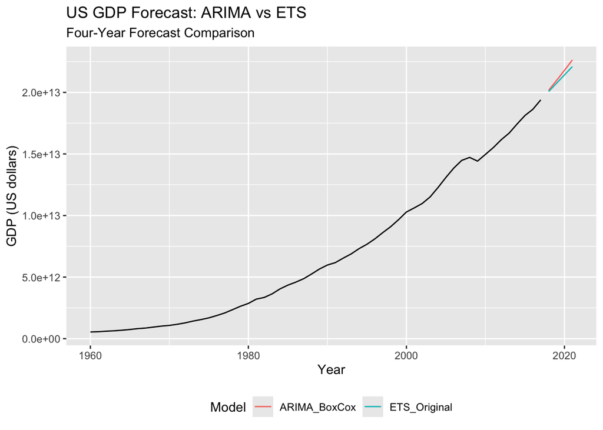

```r
# Fit both models
usa_comparison <- usa_gdp |>
  model(
    ARIMA_BoxCox = ARIMA(
      box_cox(GDP, lambda),
      stepwise = FALSE,
      approx = FALSE
    ),
    ETS_Original = ETS(GDP)
  )

# Generate 4-year forecasts
usa_fc <- usa_comparison |>
  forecast(h = 4)

# Compare point forecasts on original GDP scale
usa_fc |>
  autoplot(usa_gdp, level = NULL) +
  labs(
    title = "US GDP Forecast: ARIMA vs ETS",
    subtitle = "Four-Year Forecast Comparison",
    x = "Year",
    y = "GDP (US dollars)",
    colour = "Model"
  ) +
  theme(legend.position = "bottom")
```

```r
usa_fc |>
  as_tibble() |>
  select(.model, Year, .mean)
```

```
# A tibble: 8 × 3
  .model        Year   .mean
  <chr>        <dbl>   <dbl>
1 ARIMA_BoxCox  2018 2.02e13
2 ARIMA_BoxCox  2019 2.10e13
3 ARIMA_BoxCox  2020 2.18e13
4 ARIMA_BoxCox  2021 2.26e13
5 ETS_Original  2018 2.01e13
6 ETS_Original  2019 2.07e13
7 ETS_Original  2020 2.14e13
8 ETS_Original  2021 2.21e13
```

**##Interpretation:**

Both the ARIMA and ETS models forecast continued growth in United States GDP over the next four years. The ARIMA model incorporates first-order differencing and an autoregressive term, while the ETS model represents the series through exponential smoothing components. Comparing their forecasts on the original GDP scale makes it possible to evaluate differences in predicted growth. The models may produce different forecast values and prediction intervals because they represent the underlying time series dynamics differently. Additional forecast accuracy testing would help determine which model provides more reliable predictions.